# Module 6: Introductory Data Visualization

First off, "Introductory Data Visualization" is kind of a lie. Most introductory data visualization lessons start with R's Base Graphics methods like `plot()`. I'm skipping past that and jumping right into plotting with `ggplot2()`. The reasons are simple:

- I never use Base R plotting methods
- Therefore, I'm not a good resource for information on Base R plots
- I use `ggplot2()` exclusively for data visualization
- Therefore, I'm a slightly above average resource for data visualization using `ggplot()` methods.

## How To

I'm organizing this module as sort of a gallery. My intention here is to illustrate some useful and interesting graphics that can be constructed with some data and a little bit of `ggplot()` competency.

The `ggplot()` environment is not haphazard. It is based on a rigorous methodology for effective data display. I don't know very much about the information theory-type foundation of `ggplot`. I use it primarily because I find the way that various components (data, aestetics, geometries) are combined to form a layer to be very intuitive. I also really like the ease with which `ggplot` combines layers to form a graphic.

If you are interested in the information theory underlying the `ggplot` plot approach to graphics here are 3 resources I recommend:

1. [The ggplot2 summary from the tidyverse page](https://ggplot2.tidyverse.org/)
2. [This helpful bookdown on the grammar of graphics](https://ramnathv.github.io/pycon2014-r/visualize/ggplot2.html)
3. [Hadley Wickham's article, *A layered grammar of graphics* from *Journal of Computational and Graphical Statistics*](https://www.tandfonline.com/doi/abs/10.1198/jcgs.2009.07098)

If you're more interested in learning `ggplot` by pushing a bunch of buttons in a semi-structured but still pretty ad-hoc manner then the rest of this Module should get you pretty fired up.

## Scatterplots

Scatter plots were a pretty foundational part of my economics training. Most of us at some point probably very early in our Social Science journey were exposed to the scatter plot as the primary illustration of the technique of linear regression.

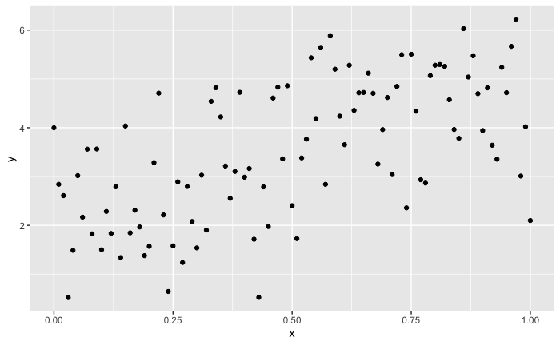

```r
# plain vanilla scatter plot of a linear relationship with noise
beta <- 3
x <- seq(0,1,by=0.01)
y <- 2 + (beta*x) + rnorm(101)
df <- data.frame(y=y,x=x)
ggplot(data=df,aes(x=x,y=y)) + geom_point()
```

Things to note from the plot above:

1. `ggplot` operates with data frames. This is somewhat distinct from Base R where we could produce a scatter plot using to vectors with something like `plot(x=x,y=y)`. When using `ggplot` to make graphics we organize our data as a `data.frame` object before passing arguments to the plot command.
2. The `ggplot()` method accepts the arguments `data` and `aes()` for aestetic.
3. Once we have told `ggplot()` what we data we want to plot (df) and how those data are to be related in the plot (x=x, y=y), we then tell it what kind of plot we want to display (`geom_point()`)

To put some emphasis on this "layering" approach, observe the following:

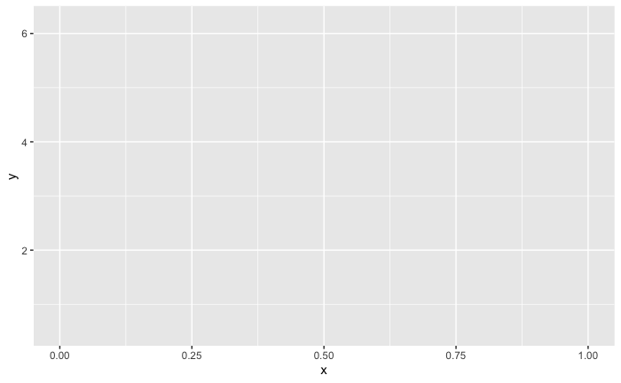

```r
plot <- ggplot(df,aes(x=x,y=y))
plot
```

Here we gave `ggplot()` the basic info it needs to prepare a plot space (some data and an aestetic) but haven't yet told it how we want the data displayed. So we add the line `+ geom_point()`:

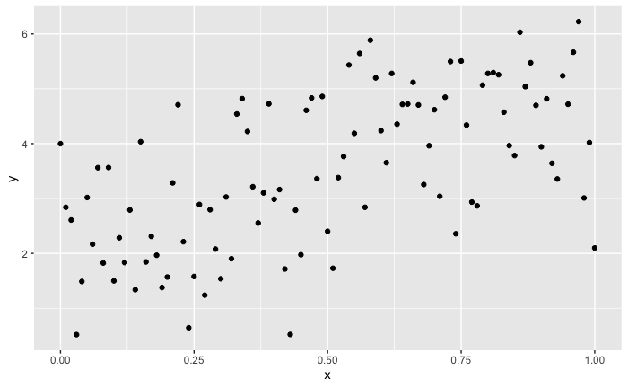

```r
plot + geom_point()
```

### Adding Layers

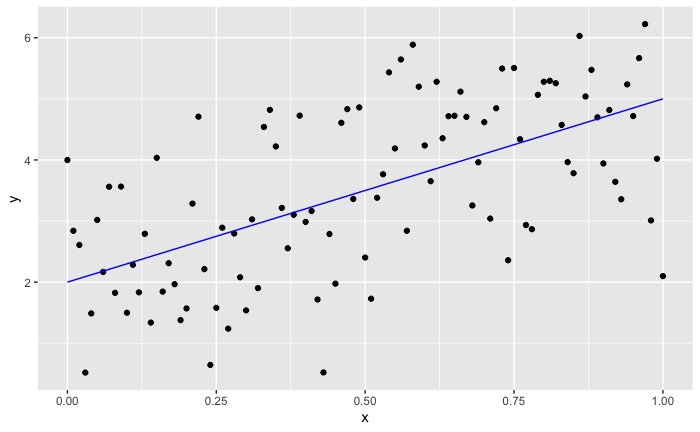

```r
# add the line from the known data generating process
df <- df %>% mutate(y_line = 2 + (beta*x))
plot + geom_point() + geom_line(data=df,aes(x=x,y=y_line),color="blue")
```

And here is a little bonus: `ggplot2()` has a method for fitting a line to data. To fit a least squares line to noisy data we can use `geom_smooth(method=lm)`:

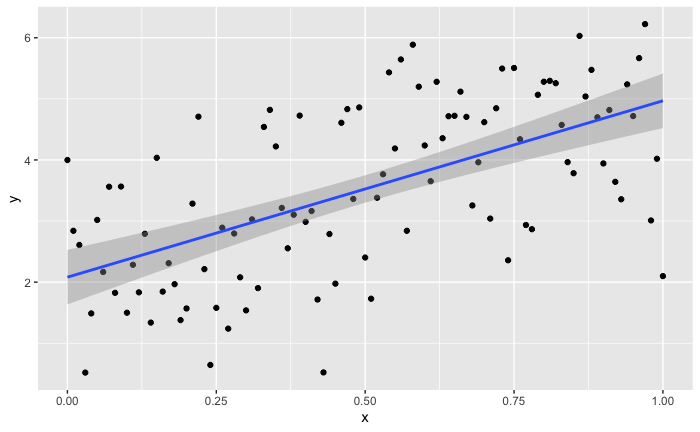

```r
plot + geom_point() + geom_smooth(method=lm)
```

### Modifying the Plot Space

Here is an example of a couple common enhancements I often end up adding to plots:

1. named x and y axes
2. formatted axis tick labels
3. a nicer theme - I use the `ggthemes` package to get access to a bunch of canned themes.

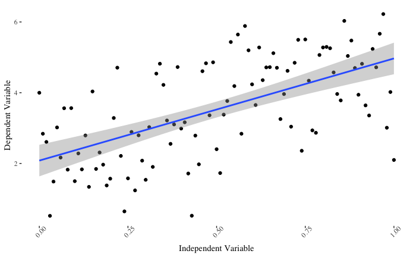

```r
plot + geom_point() + geom_smooth(method=lm) +
   theme_tufte() + xlab("Independent Variable") +
     ylab("Dependent Variable") +
       theme(axis.text.x=element_text(angle=45))
```

## Plotting Distributions

Here are a few distributional plots that I use frequently.

### Box Plots

Basic box plot

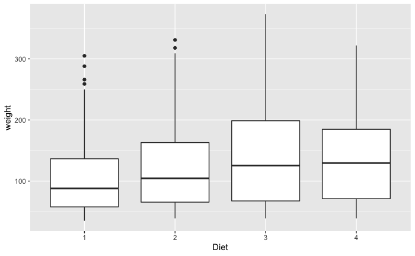

```r
#plain vanilla boxplot with the ChickWeights data (R has a bunch of toy data sets that
#   one can bring into a workspace with the method data())
# read about these data sets here:
#  https://stat.ethz.ch/R-manual/R-patched/library/datasets/html/00Index.html
data(ChickWeight)
ggplot(subset(ChickWeight,Time=10),aes(x=Diet,y=weight)) + geom_boxplot()
```

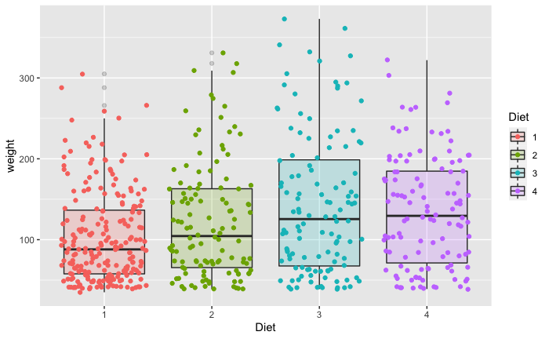

```r
ggplot(subset(ChickWeight,Time=10),aes(x=Diet,y=weight,fill=Diet)) + geom_boxplot(alpha=0.2) +
   geom_jitter(aes(colour=Diet))
```

Grouping variables in boxplots can be useful for things like visualizing changes in seasonal variation over long time horizons:

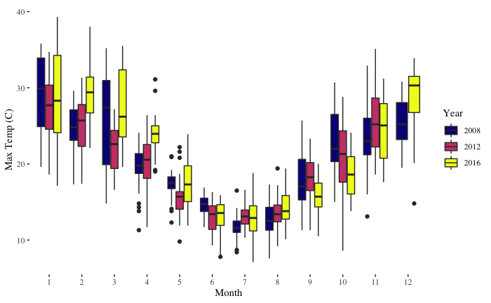

```r
# Daily Data from Kaggle on Weather in Australia 2007-2017.
# https://www.kaggle.com/jsphyg/weather-dataset-rattle-package
aus <- read.csv('data/weatherAUS.csv') %>%
        mutate(date=as.Date(Date))
can <- aus %>% mutate(month=month(Date),year=year(Date)) %>%
         filter(Location=='Canberra' & year %in% c(2008,2012,2016))

ggplot(can,aes(x=factor(month),y=MaxTemp,fill=factor(year))) + geom_boxplot() +
      scale_fill_viridis_d(option='plasma', name="Year") +
      theme_tufte() + ylab("Max Temp (C)") + xlab("Month")
```

### Histograms

A histogram is particular kind of bar chart and `ggplot` has a geometry method for constructing histograms. Histograms are often used to visualize the range and shape of a data series. Is it single-peaked or multi-modal? Does it look approximately normally distributed? etc.

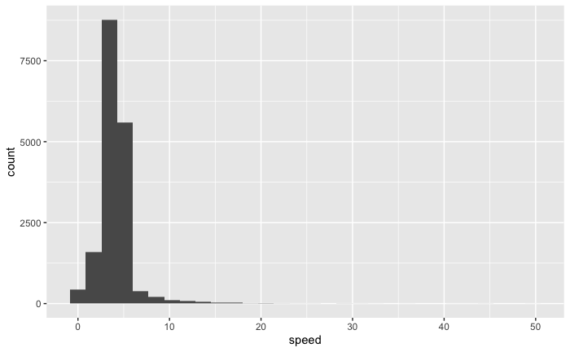

```r
# read in a sample of some VMS observation I have from groundfish trawlers
vms <- read.csv('data/vms_fishing_export.csv') %>%
        mutate(date_time=as.POSIXct(date_time,format='%Y-%m-%d %H:%M:%S')) %>%
         filter(year(date_time)==2014) %>%
           mutate(activity=ifelse(fishing==1,"fishing","not fishing"))

ggplot(vms %>% filter(fishing==1 & speed < 50),aes(x=speed)) + geom_histogram()
```

Histograms can compare two distributions.

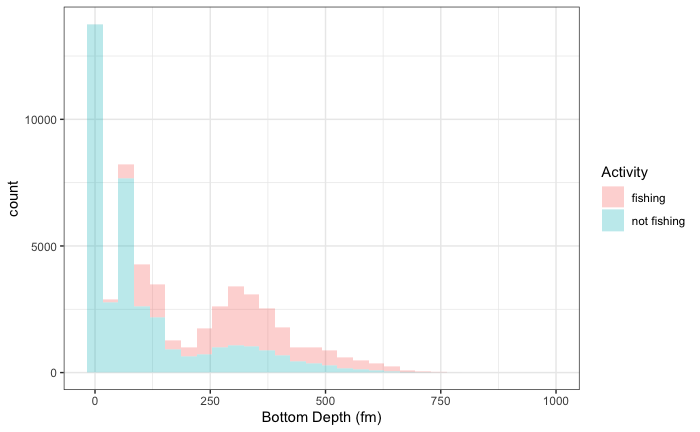

```r
ggplot(vms,aes(x=depth.fm,fill=factor(activity))) + geom_histogram(alpha=0.3) +
    scale_fill_discrete(name="Activity") + theme_bw() + xlab("Bottom Depth (fm)")
```

### Density Plots

Another way to visualize teh distribution of a variable is with density plots.

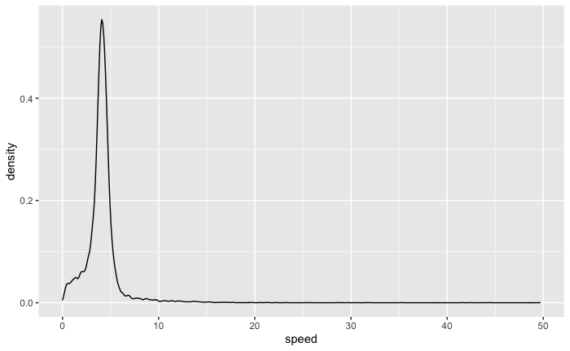

```r
# A simple density plot
ggplot(vms %>% filter(fishing==1 & speed < 50),aes(x=speed)) + geom_density()
```

```r
ggplot(subset(vms,fishing==1),aes(x=speed)) + geom_density() +
   geom_density(subset(vms,fishing==0),aes(x=-speed))
```

[output not shown]

```
Error: `mapping` must be created by `aes()`
Run `rlang::last_error()` to see where the error occurred.
```

## Time-Series Plots

I'm taking this example straight from the [R Graph Gallery Page](https://www.r-graph-gallery.com/163-interactive-area-chart-plotly.html). It's an interactive time-series plot of bitcoin prices.

```r
library(plotly)
# Load dataset from github
bitcoin <- read.table("https://raw.githubusercontent.com/holtzy/data_to_viz/master/Example_dataset/3_TwoNumOrdered.csv", header=T)
bitcoin$date <- as.Date(bitcoin$date)
bitcoin <- bitcoin %>% filter(year(date)>=2015)
# Usual area chart
p <- bitcoin %>%
  ggplot( aes(x=date, y=value)) +
    geom_area(fill="#69b3a2", alpha=0.5) +
    geom_line(color="#69b3a2") +
    ylab("bitcoin price ($)") +
    scale_y_continuous(breaks=c(0,5000,10000,15000,20000),
                       labels=c("0","5","10","15","20K")) +
    theme_ipsum()
# Turn it interactive with ggplotly
p <- ggplotly(p)
p
```

[output not shown]

## Just 4 Fun

From [fivethirtyeight.com, *Why we're 3 million russian troll tweets](https://fivethirtyeight.com/features/why-were-sharing-3-million-russian-troll-tweets/)

Original data from Clemson University: [Troll Factories: The Internet Research Agency and State-Sponsored Agenda Building](http://pwarren.people.clemson.edu/Linvill_Warren_TrollFactory.pdf)

```r
ira1 <- read.csv("https://raw.githubusercontent.com/fivethirtyeight/russian-troll-tweets/master/IRAhandle_tweets_1.csv")
ira2 <- read.csv("https://raw.githubusercontent.com/fivethirtyeight/russian-troll-tweets/master/IRAhandle_tweets_2.csv")
ira3 <- read.csv("https://raw.githubusercontent.com/fivethirtyeight/russian-troll-tweets/master/IRAhandle_tweets_3.csv")
ira4 <- read.csv("https://raw.githubusercontent.com/fivethirtyeight/russian-troll-tweets/master/IRAhandle_tweets_4.csv")
ira5 <- read.csv("https://raw.githubusercontent.com/fivethirtyeight/russian-troll-tweets/master/IRAhandle_tweets_5.csv")
ira6 <- read.csv("https://raw.githubusercontent.com/fivethirtyeight/russian-troll-tweets/master/IRAhandle_tweets_6.csv")
ira7 <- read.csv("https://raw.githubusercontent.com/fivethirtyeight/russian-troll-tweets/master/IRAhandle_tweets_7.csv")
ira8 <- read.csv("https://raw.githubusercontent.com/fivethirtyeight/russian-troll-tweets/master/IRAhandle_tweets_8.csv")
ira9 <- read.csv("https://raw.githubusercontent.com/fivethirtyeight/russian-troll-tweets/master/IRAhandle_tweets_9.csv")
ira10 <- read.csv("https://raw.githubusercontent.com/fivethirtyeight/russian-troll-tweets/master/IRAhandle_tweets_10.csv")
ira11 <- read.csv("https://raw.githubusercontent.com/fivethirtyeight/russian-troll-tweets/master/IRAhandle_tweets_11.csv")
ira12 <- read.csv("https://raw.githubusercontent.com/fivethirtyeight/russian-troll-tweets/master/IRAhandle_tweets_12.csv")
ira13 <- read.csv("https://raw.githubusercontent.com/fivethirtyeight/russian-troll-tweets/master/IRAhandle_tweets_13.csv")
tweets <- data.frame(date=c(ira1$publish_date,
                                ira2$publish_date,
                                ira3$publish_date,
                                ira4$publish_date,
                                ira5$publish_date,
                                ira6$publish_date,
                                ira7$publish_date,
                                ira8$publish_date,
                                ira9$publish_date,
                                ira10$publish_date,
                                ira11$publish_date,
                                ira12$publish_date,
                                ira13$publish_date),
                     tweet=1) %>%
              mutate(date=as.Date(date,format="%m/%d/%Y")) %>%
              group_by(date) %>% summarise(tweet=sum(tweet,na.rm=T))
```

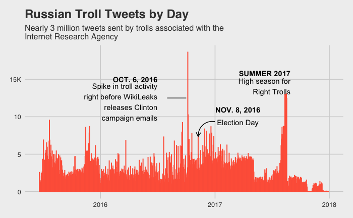

```r
tweets <- tweets %>% filter(date>'2015-06-19' & date < '2017-12-31')
ggplot(tweets,aes(x=date,y=tweet)) + geom_bar(stat='identity',color="tomato") +
  annotate("text", x = as.Date("2016-07-01"), y = 15000,
                    label = "OCT. 6, 2016",
                    fontface =2,
                    hjust=1) +
  annotate("text", x = as.Date("2016-07-01"), y = 12000,
                    label = "Spike in troll activity\nright before WikiLeaks\nreleases Clinton\ncampaign emails",
                    fontface =1,
                    hjust=1) +
  geom_segment(data=data.frame(xstart=as.Date('2016-08-01'),xend=as.Date('2016-10-01'),ystart=12500,yend=12500),
               aes(x=xstart,xend=xend,y=ystart,yend=yend)) +
  geom_curve(aes(x = x2, y = y2, xend = x1, yend = y1),
             data = data.frame(x1=as.Date('2016-11-08'),
                               x2=as.Date('2017-01-01'),
                               y1=tweets$tweet[which(tweets$date=='2016-11-08')],
                               y2=tweets$tweet[which(tweets$date=='2016-11-08')]+2000),
             arrow = arrow(length = unit(0.03, "npc"))) +
  annotate("text",x=as.Date("2017-01-02"),y=10000,
                            label='atop(bold("NOV. 8, 2016"),"Election Day")',parse=T,hjust=0) +
  annotate("text",x=as.Date("2017-08-30"),y=15800,
                            label="SUMMER 2017",
                            fontface=2,hjust=1) +
  annotate("text",x=as.Date("2017-08-30"),y=14100,
                            label="High season for\nRight Trolls",
                            fontface=1,hjust=1) +
  scale_colour_fivethirtyeight() +
  ggtitle(label = "Russian Troll Tweets by Day",
              subtitle = "Nearly 3 million tweets sent by trolls associated with the\nInternet Research Agency") +
  scale_y_continuous(breaks=c(0,5000,10000,15000),
        labels=c("0", "5", "10","15K")) +
  theme_fivethirtyeight()
```

FiveThirtyEight uses a font called [Decima Mono](https://www.typewolf.com/site-of-the-day/fonts/decima-mono). Honestly, I googled around to see if I could use this font in a ggplot plot...but I didn't make much progress and ultimately gave up.

## Resources

Once in a while you'll see a question posted to Stack Overflow or some other code list serve that's met with an RTFM (read the *&^%# manual) response from a salty programmer. So here's the ggplot2 manual:

[The ggplot2 manual](https://cran.r-project.org/web/packages/ggplot2/ggplot2.pdf) The ggplot2 page in the tidyverse

Resources like the library documentation on CRAN are generally not great for questions like

- [Can I use math type in a text annotation?](https://www.benjaminackerman.com/post/2019-03-08-equation_labels/)

But if your question is *how do I make the dots on my scatter plot blue instead of black?* You should probably expect salty programmers to scream RTFM at you because the manual tells you very clearly what options you can stuff inside `geom_point(...)` to change the appearance of your plot.